# 🏠 Welcome to the Airbnb Mini Practice Project 🏠

[figure not shown]

As you've worked through the intermediate Python resources you would have realised there are a number of powerful functions you can use!

You would have covered the following libraries:

Matplotlib

Pandas

These are all powerful libraries to help augment your data analysis capabilities. In these set of exercises below, we've crafted a few extra challenges to reinforce your understanding of how these libraries work.

Please note there is a particular emphasis on the Pandas Library as this is the most critical library you will be using throughout your career as a data analyst. You'll see the similarities that hold with respect to Pandas and Pivot Tables!

**`The most important thing to build confidence with Python is to practice all the time. This way you will build muscle memory. Don't simply copy the code you've written previously but write it again and again so you build the muscle memory associated with these coding libraries.`**

### Let's get started!

For simplicity, we've included a direct link to the `CSV` file that we've stored in this variable called data_source. This means rather than having to *download* the `CSV` file onto your machine, you can do store the file in your Notebook!

We've done this for you officially in Step 1 to get you started!

**Note: It'll take a couple of seconds to have the file downloaded into your Notebook.**

### 1: Import Libraries and Read In Data

Import the pandas library and ingest the `Airbnb` data stored in the data_source variable using the `pd.read_csv()` function.

We've printed out the first five rows of data using the `.head()` method you can familiarize yourself with!

### Run the code below to import the airbnb_dataframe into your Notebook!

```python
import pandas as pd
import matplotlib.pyplot as plt
plt.style.use('ggplot')
plt.rcParams['figure.figsize'] = (20,10) #Setting up the plotting visualization range
import warnings
warnings. filterwarnings('ignore')
data_source = 'https://raw.github.com/chrishuisb1990/practice_datasets/main/airbnb_nyc.csv'
airbnb_dataframe = pd.read_csv(data_source)
airbnb_dataframe.head()
```

|  | id | name | host_id | host_name | neighbourhood_group | neighbourhood | latitude | longitude | room_type | price | minimum_nights | number_of_reviews | last_review | reviews_per_month | calculated_host_listings_count | availability_365 |
| --- | --- | --- | --- | --- | --- | --- | --- | --- | --- | --- | --- | --- | --- | --- | --- | --- |
| 0 | 2539 | Clean & quiet apt home by the park | 2787 | John | Brooklyn | Kensington | 40.64749 | -73.97237 | Private room | 149 | 1 | 9 | 19/10/2018 | 0.21 | 6 | 365 |
| 1 | 2595 | Skylit Midtown Castle | 2845 | Jennifer | Manhattan | Midtown | 40.75362 | -73.98377 | Entire home/apt | 225 | 1 | 45 | 21/05/2019 | 0.38 | 2 | 355 |
| 2 | 3647 | THE VILLAGE OF HARLEM....NEW YORK ! | 4632 | Elisabeth | Manhattan | Harlem | 40.80902 | -73.94190 | Private room | 150 | 3 | 0 | NaN | NaN | 1 | 365 |
| 3 | 3831 | Cozy Entire Floor of Brownstone | 4869 | LisaRoxanne | Brooklyn | Clinton Hill | 40.68514 | -73.95976 | Entire home/apt | 89 | 1 | 270 | 5/07/2019 | 4.64 | 1 | 194 |
| 4 | 5022 | Entire Apt: Spacious Studio/Loft by central park | 7192 | Laura | Manhattan | East Harlem | 40.79851 | -73.94399 | Entire home/apt | 80 | 10 | 9 | 19/11/2018 | 0.10 | 1 | 0 |

**As you work through the questions below, you'll be focused on reinforcing the following fundamental principles:**

Subsetting a Pandas dataframe using the `explicit selection method []` and `boolean filters`

Using a new method, .value_counts() to count the unique number of records in a specific column

Aggregation Operatins in Pandas using the `.groupby()` syntax

Creating Bar Plots using the `.plot(kind='bar')` syntax

### 2: Exploring your data with Pandas

It's common to want to check how many times a textual criteria might appear in a column. Say for example, we're interested in understanding how many times an item was sold in a row of transactions.

We could simply perform a operation like the below:

`dataframe.groupby(['column']).count()`

Let's imagine we're interested in counting the `number of room_types` on offer for our airbnb dataset.

We could simply write:

`airbnb_dataframe.groupby(['room_type']).count()`

This would give us the below result:

```python
airbnb_dataframe.groupby(['room_type']).count()
```

| room_type | id | name | host_id | host_name | neighbourhood_group | neighbourhood | latitude | longitude | price | minimum_nights | number_of_reviews | last_review | reviews_per_month | calculated_host_listings_count | availability_365 |
| --- | --- | --- | --- | --- | --- | --- | --- | --- | --- | --- | --- | --- | --- | --- | --- |
| Entire home/apt | 25409 | 25402 | 25409 | 25400 | 25409 | 25409 | 25409 | 25409 | 25409 | 25409 | 25409 | 20332 | 20332 | 25409 | 25409 |
| Private room | 22326 | 22318 | 22326 | 22314 | 22326 | 22326 | 22326 | 22326 | 22326 | 22326 | 22326 | 17665 | 17665 | 22326 | 22326 |
| Shared room | 1160 | 1159 | 1160 | 1160 | 1160 | 1160 | 1160 | 1160 | 1160 | 1160 | 1160 | 846 | 846 | 1160 | 1160 |

However, we aren't interested in all the other columns. If we **ONLY** want the COUNT of all records with respect to each unique room_type, we can achieve this using the `.value_counts()` methodology.

An example of the syntax is below:

`airbnb_dataframe['room_type'].value_counts()`

Now with this new found knowledge, let's see you implement this!

We're interested in understanding more about our hosts. Maybe we can identify the hosts which might have the largest number of `airbnb` properties using the `host_id` as an initial proxy?

Let's answer this question using the `.value_counts()` methodology!

**A. Using the `.value_counts()` methodology we've shown above, show the number of listings each airbnb `host_id` has and subset this to include the top 20 hosts.**

### Write your answer below

```python
airbnb_dataframe['host_id'].value_counts().head(20)
```

```
host_id
219517861    327
107434423    232
30283594     121
137358866    103
16098958      96
12243051      96
61391963      91
22541573      87
200380610     65
7503643       52
1475015       52
120762452     50
2856748       49
205031545     49
190921808     47
26377263      43
2119276       39
19303369      37
119669058     34
25237492      34
Name: count, dtype: int64
```

## Sample Output

```
219517861    327
107434423    232
30283594     121
137358866    103
16098958      96
12243051      96
61391963      91
22541573      87
200380610     65
7503643       52
1475015       52
120762452     50
2856748       49
205031545     49
190921808     47
26377263      43
2119276       39
19303369      37
119669058     34
25237492      34
Name: host_id, dtype: int64
```

It does appear that there are a handful of airbnb hosts that have a large number of potential properties! Let's work off the assumption that all these airbnbs have different `name` descriptions that emphasize whether the property is unique or not.

**B. Using the results from the `value_counts` exercise you completed above, subset the airbnb_dataframe to include only the top 20 hosts you previously identified. Store the results of your subsetted_dataframe into a dataframe called `host_dataframe`.**

Hint: If you can't remember how to subset, reference the cheatsheet at the bottom of this exercise!

You'll need to store the results from your `value_counts` operation into a variable and then use this to subset your dataframe accordingly.

We've included an example of what the steps would look like:

1. Store your results of your .value_counts() operation into a variable

   `variable = dataframe['column'].value_counts().head(20)`

   This stores the results of the top 20 results into a variable called condition
2. Access the host_ids that make up the top 20 using the .reset_index() method

   `id_list = variable.reset_index()['index']`

   The Value Counts is a `GROUP BY COUNT` implementation. As such, we can reset the index and access the list of host IDs that are now stored under the variable called index.
3. Subset your dataframe using the `id_list` that now contains the top 20 host IDs you have extracted

   At this point, we assume you're comfortable subsetting so we won't include any additional hints here beyond the Appendix at the bottom of this exercise.

### Write your answer below

```python
host_houses = airbnb_dataframe['host_id'].value_counts().head(20)
id_list = host_houses.reset_index()['host_id']
host_dataframe = airbnb_dataframe[airbnb_dataframe['host_id'].isin(id_list)]
print(host_dataframe.head())
```

```
          id                                               name  host_id  \
1386  613556                2 BED TriBeCa, Beautiful-Renovated!  1475015
1454  652371                ELEGANT MIDTOWN EAST STUDIO E.52 ST  1475015
1455  652466  32nd St & Lexington Ave / Doorman Beautiful St...  1475015
1456  652515                 COLUMBUS CIRCLE~FULLY FURNISHED!!!  1475015
1457  652648                GRAMERCY PARK~FURNISHED E.20's ST P  1475015

     host_name neighbourhood_group   neighbourhood  latitude  longitude  \
1386      Mike           Manhattan         Tribeca  40.71655  -74.01171
1454      Mike           Manhattan         Midtown  40.75743  -73.96939
1455      Mike           Manhattan        Kips Bay  40.74190  -73.98160
1456      Mike           Manhattan  Hell's Kitchen  40.76758  -73.98722
1457      Mike           Manhattan        Kips Bay  40.74189  -73.97833

            room_type  price  minimum_nights  number_of_reviews last_review  \
1386  Entire home/apt    130              30                  2  31/10/2015
1454  Entire home/apt     90              30                  3  31/12/2016
1455  Entire home/apt    100              30                  2  30/06/2018
1456  Entire home/apt     85              30                  2  15/08/2016
1457  Entire home/apt     87              30                  3  15/08/2018

      reviews_per_month  calculated_host_listings_count  availability_365
1386               0.03                              52               116
1454               0.05                              52               358
1455               0.04                              52               342
1456               0.04                              52               223
1457               0.05                              52               363
```

## Sample Output

|  | id | name | host_id | host_name | neighbourhood_group | neighbourhood | latitude | longitude | room_type | price | minimum_nights | number_of_reviews | last_review | reviews_per_month | calculated_host_listings_count | availability_365 |
| --- | --- | --- | --- | --- | --- | --- | --- | --- | --- | --- | --- | --- | --- | --- | --- | --- |
| 1386 | 613556 | 2 BED TriBeCa, Beautiful-Renovated! | 1475015 | Mike | Manhattan | Tribeca | 40.71655 | -74.01171 | Entire home/apt | 130 | 30 | 2 | 31/10/2015 | 0.03 | 52 | 116 |
| 1454 | 652371 | ELEGANT MIDTOWN EAST STUDIO E.52 ST | 1475015 | Mike | Manhattan | Midtown | 40.75743 | -73.96939 | Entire home/apt | 90 | 30 | 3 | 31/12/2016 | 0.05 | 52 | 358 |
| 1455 | 652466 | 32nd St & Lexington Ave / Doorman Beautiful St... | 1475015 | Mike | Manhattan | Kips Bay | 40.74190 | -73.98160 | Entire home/apt | 100 | 30 | 2 | 30/06/2018 | 0.04 | 52 | 342 |
| 1456 | 652515 | COLUMBUS CIRCLE~FULLY FURNISHED!!! | 1475015 | Mike | Manhattan | Hell's Kitchen | 40.76758 | -73.98722 | Entire home/apt | 85 | 30 | 2 | 15/08/2016 | 0.04 | 52 | 223 |
| 1457 | 652648 | GRAMERCY PARK~FURNISHED E.20's ST P | 1475015 | Mike | Manhattan | Kips Bay | 40.74189 | -73.97833 | Entire home/apt | 87 | 30 | 3 | 15/08/2018 | 0.05 | 52 | 363 |

Now that we've got our dataframe, it's time for us to validate the number of properties each host_id may have. We're going to validate this using the combination of `host_id` and `name`, assuming that the combination of these two fields, will help us understand how many properties each airbnb host might have!

**C. Using the `host_dataframe` you created, group the dataframe by `host_id` and `name` to identify the total number of properties each `host_id` may really have using the `.count()` aggregate method.**

To successfully answer this question will require a few steps:

1. You'll need to GROUP BY the `host_id` and `name` to get groupings like the below:

```python
host_dataframe.groupby(['host_id','name']).count().head()
```

| host_id | name | id | host_name | neighbourhood_group | neighbourhood | latitude | longitude | room_type | price | minimum_nights | number_of_reviews | last_review | reviews_per_month | calculated_host_listings_count | availability_365 |
| --- | --- | --- | --- | --- | --- | --- | --- | --- | --- | --- | --- | --- | --- | --- | --- |
| 1475015 | AMAZING TIME SQUARE!!BRICK WALLS!! | 1 | 1 | 1 | 1 | 1 | 1 | 1 | 1 | 1 | 1 | 1 | 1 | 1 | 1 |
|  | 2 BED TriBeCa, Beautiful-Renovated! | 1 | 1 | 1 | 1 | 1 | 1 | 1 | 1 | 1 | 1 | 1 | 1 | 1 | 1 |
|  | 32nd St & Lexington Ave / Doorman Beautiful Studio | 1 | 1 | 1 | 1 | 1 | 1 | 1 | 1 | 1 | 1 | 1 | 1 | 1 | 1 |
|  | 5 STARS***MIDTOWN EAST-BRAND NEW!!! | 1 | 1 | 1 | 1 | 1 | 1 | 1 | 1 | 1 | 1 | 1 | 1 | 1 | 1 |
|  | 76 St & 2 Ave /Renovated studio/ Elevator/ Laundry | 1 | 1 | 1 | 1 | 1 | 1 | 1 | 1 | 1 | 1 | 1 | 1 | 1 | 1 |

2. Reset the index after your GROUP BY so `host_id` and `name` are columns once more

   `dataframe.groupby(['host_id','name']).reset_index()`
3. Lastly, **re-group** by `host_id`, apply the .count() aggregation and store this in a variable called `host_dataframe_name`!

### Write your answer below

```python
host_grouped = host_dataframe.groupby(['host_id','name']).count().reset_index()
host_dataframe_name = host_grouped.groupby(['host_id']).count()
print(host_dataframe_name.head(10))
```

```
          name  id  host_name  neighbourhood_group  neighbourhood  latitude  \
host_id
1475015     52  52         52                   52             52        52
2119276     38  38         38                   38             38        38
2856748     49  49         49                   49             49        49
7503643     52  52         52                   52             52        52
12243051    96  96         96                   96             96        96
16098958    96  96         96                   96             96        96
19303369    37  37         37                   37             37        37
22541573    63  63         63                   63             63        63
25237492    34  34         34                   34             34        34
26377263    43  43         43                   43             43        43

          longitude  room_type  price  minimum_nights  number_of_reviews  \
host_id
```

[output cut: 36 more lines]

## Sample Output

| host_id | name | id | host_name | neighbourhood_group | neighbourhood | latitude | longitude | room_type | price | minimum_nights | number_of_reviews | last_review | reviews_per_month | calculated_host_listings_count | availability_365 |
| --- | --- | --- | --- | --- | --- | --- | --- | --- | --- | --- | --- | --- | --- | --- | --- |
| 219517861 | 311 | 311 | 311 | 311 | 311 | 311 | 311 | 311 | 311 | 311 | 311 | 311 | 311 | 311 | 311 |
| 107434423 | 231 | 231 | 231 | 231 | 231 | 231 | 231 | 231 | 231 | 231 | 231 | 231 | 231 | 231 | 231 |
| 30283594 | 121 | 121 | 121 | 121 | 121 | 121 | 121 | 121 | 121 | 121 | 121 | 121 | 121 | 121 | 121 |
| 137358866 | 103 | 103 | 103 | 103 | 103 | 103 | 103 | 103 | 103 | 103 | 103 | 103 | 103 | 103 | 103 |
| 12243051 | 96 | 96 | 96 | 96 | 96 | 96 | 96 | 96 | 96 | 96 | 96 | 96 | 96 | 96 | 96 |

Great job so far! We can see that we have some different results from our first `.value_counts()` approach. Now it's time to visualize our results using a bar chart!

**D. Create a Bar Chart that shows the number of properties each `host_id` has utilizing the `host_dataframe_name` you created in the previous question.**

### Write your answer below

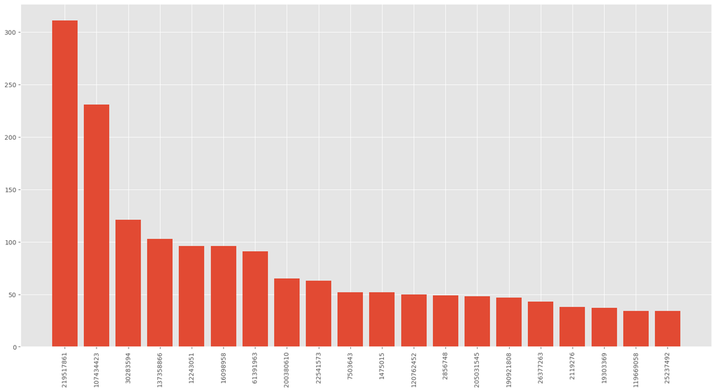

```python
host_grouped = host_dataframe.groupby(['host_id','name']).count().reset_index()
host_dataframe_name = host_grouped.groupby(['host_id']).count().reset_index()
host_dataframe_name_sort = host_dataframe_name.sort_values(by='name', ascending=False)
fig, ax = plt.subplots()
ax.bar(host_dataframe_name_sort['host_id'].astype('str'), host_dataframe_name_sort['name'])
ax.set_xticklabels(host_dataframe_name_sort['host_id'], rotation=90)
plt.show()
```

## Sample Output

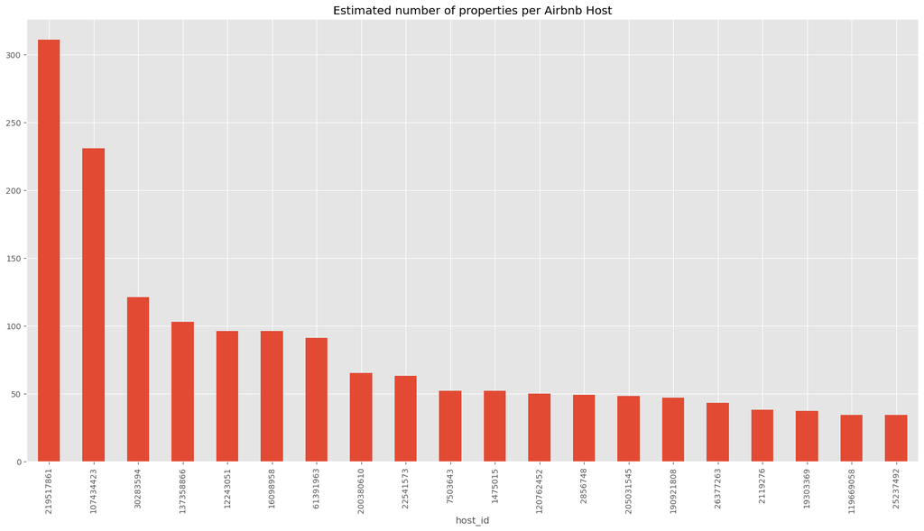

# Challenge Question

Now let's move away from just looking at hosts, where we want to understand, which neighbourhoods have the best revenue performance within the `neighbourhood_group`, `Manhattan`, `Brooklyn` and `Queens`.

You would note that there isn't a revenue field in our dataset, you're going to have make one utilizing the following logic:

`dataframe['revenue'] = dataframe['price'] * dataframe['number_of_reviews']`

Whilst we can't get the exact revenue, this should be an efficient proxy for us to give us an idea regarding which neighbourhoods and hosts bring in the majority of revenues.

Upon completion of this, identify the `top 3 Revenue Generating Neighborhoods` within each of the `three Neighbourhood_Groups`. This should give us 9 Overall Rows: 3 of the top generating neighbourhoods within each of the 3 Neighbourhood_Groups

**Step One - Create the Revenue column in your airbnb dataframe**

**Step Two - Filter the Dataframe to include only the neighbourhood groups specified (i.e. Manhattan, Brooklyn, Queens)**

You can make use of the `.isin()` syntax to help filter on multiple conditions in a cleaner manner!

```
dataframe['SomeColumn'].isin(['A','B','C'])
```

**Step Three - Group the Data by `Neighbourhood_Group` and `Neighbourhood` with respect to `Revenue`**

Remember the dataframe syntax for grouping by is:

`dataframe.groupby(['SomeColumn']).someAggregation()`

**Step Four - Identify the `top 3 Revenue Generating Neighborhoods` within each of the `three Neighbourhood_Groups`. This should give us 9 Overall Rows: 3 of the top revenue generating neighbourhoods within each of the 3 `Neighbourhood_Groups` This is where you'll need to make use of the following functions: `dataframe.reset_index()` `dataframe.groupby()` `dataframe.head()`**

You will want to make use of the .reset_index(inplace=True) function to help reset the indexes in your Grouped Up Dataframe...!

### Write your answer below

```python
airbnb_dataframe['Revenue'] = airbnb_dataframe['price'] * airbnb_dataframe['number_of_reviews']
airbnb_filter = airbnb_dataframe[airbnb_dataframe['neighbourhood_group'].isin(['Manhattan','Brooklyn','Queens'])]
airbnb_filter.groupby(['Revenue']).sum()
revenue_by_neighbourhood = (airbnb_filter.groupby(['neighbourhood_group', 'neighbourhood'])['Revenue'].sum().reset_index())
top_neighbourhoods = (revenue_by_neighbourhood.sort_values(['neighbourhood_group', 'Revenue'], ascending=[True, False]).groupby('neighbourhood_group').head(3).reset_index(drop=True))
print(top_neighbourhoods)
```

```
  neighbourhood_group       neighbourhood   Revenue
0            Brooklyn        Williamsburg  12389011
1            Brooklyn  Bedford-Stuyvesant  12352457
2            Brooklyn            Bushwick   4762224
3           Manhattan              Harlem   8598692
4           Manhattan      Hell's Kitchen   8238991
5           Manhattan        East Village   7574535
6              Queens             Astoria   1880840
7              Queens    Long Island City   1374945
8              Queens            Flushing   1140450
```

## Sample Output

|  | neighbourhood_group | neighbourhood | Revenue |
| --- | --- | --- | --- |
| 0 | Brooklyn | Williamsburg | 12389011 |
| 1 | Brooklyn | Bedford-Stuyvesant | 12352457 |
| 2 | Manhattan | Harlem | 8598692 |
| 3 | Manhattan | Hell's Kitchen | 8238991 |
| 4 | Manhattan | East Village | 7574535 |
| 8 | Brooklyn | Bushwick | 4762224 |
| 17 | Queens | Astoria | 1880840 |
| 28 | Queens | Long Island City | 1374945 |
| 33 | Queens | Flushing | 1140450 |

## Appendix: Python Cheat Sheet

**SELECTING COLUMNS**

```
- dataframe['a'] -- Select column a from a dataframe individually
- dataframe[['a','b']] -- Select columns a and b from a dataframe
- dataframe[:5] -- Select the first five rows from the dataframe
- dataframe[2:] -- Select all the rows of the dataframe starting from row 2 onwards
- dataframe.head(n) -- Select the number of rows in the dataframe specified by n
- dataframe.loc[row,column] -- Selects the number of rows, and columns specified with labels
- dataframe.iloc[row,column_index] -- Select the number of rows, and columns referencing their index
```

**LIBRARIES**

```
- import pandas as pd -- This imports the pandas library that contains the methods you need to manipulate tabular data
- import numpy as np -- This imports the numpy library that contains the np.where (IF) method you need to utilize
- import warnings -- This is the warning library that can be imported to either highlight or hide warning messages
- warnings. filterwarnings('ignore')--This ignores Python warning errors
- import matplotlib.pyplot as plt -- This is the visualization library needed to create plots
```

**OPERATORS**

```
- < - Less than
- > - Greater than
- <= - Less than or equal
- >= - Greater than or equal
- <> - Not equal
- = - Equal
- & - AND (e.g. dataframe['Column']>=1) & (dataframe['Column']<=2)
- | - OR
```

**DESCRIPTIVE STATISTICS FUNCTIONS**

```
- dataframe['column'].mean() - Returns the average value of a column
- dataframe['column'].min() - Returns the minimum value of a column
- dataframe['column'].max() - Returns the minimum value of a column
- dataframe['column'].sum() - Returns the sum of a column
- dataframe['column'].median() - Returns the median of a column
```

**SUBSETTING COLUMNS**

```
- dataframe['column'].isin(['A','B']) - Returns a T/F boolean list of entries matching A and B which are textual fields
- dataframe[condition] - Provided condition is a T/F boolean expression, it will return all matching entries that are
True
```

**USING NP.WHERE() AS A PROXY FOR IF STATEMENTS**

```
- np.where(dataframe['column']> 1, "Return when True", "Return when False") -- A True/False expression comparison for numerical terms.
- np.where(dataframe['column'].isin(['A','B']),"Return when True", "Return when False") -- A True/False expression comparison for textual comparisons.
```

**SORTING VALUES**

```
- dataframe.groupby(['A']).sum()[['B','C']].sort_values(by=['B'], ascending=False) -- The syntax to sort a dataframe using specific columns
- dataframe.groupby(['A']).sum()['B'].sort_values(ascending=False) -- The syntax to sort a dataframe provided you only have one numerical column to sort on.
```

**DICTIONARIES AND AGGREGATIONS**

```
- Dictionaries are special data types in Python defined by a key-value relationship.
Syntax wise, they use the {'key': 'value'} syntax
- .agg(['X','Y']) represents a advanced method of providing multiple descriptive statistics where X and Y represents aggregation functions (i.e. sum, mean, min, max etc.)
```